# Lecture 04: The `ggplot` library

## 0.1.0 A quick intro to the Introduction to R for Data Science

This 'Introduction to R for Data Science' is brought to you by the Centre for the Analysis of Genome Evolution & Function's (CAGEF) bioinformatics training initiative. This CSB1020 was developed based on feedback on the needs and interests of the Department of Cell & Systems Biology and the Department of Ecology and Evolutionary Biology.

This lesson is the fourth in a 7-part series. The idea is that at the end of the series, you will be able to import and manipulate your data, make exploratory plots, perform some basic statistical tests, test a regression model, and make some even prettier plots and documents to share your results.

The structure of the class is a code-along style: It is fully hands on. Prior to each lecture, the materials will be emailed to you and will also be available for download at [QUERCUS](https://q.utoronto.ca), so you can spend more time coding than taking notes.

## 0.1.1 Class Objectives

At the end of this session you will be able to use `ggplot2` to make a ton of different types of plots with your data for both data exploration and for publication-quality figures.

1. Introduction to `ggplot` and the grammar of graphics using scatterplots
2. Exploring other types of plots
3. Customizing your plots
4. Saving your plots
5. Taking your plots up a notch
6. Resources
7. Appendix

## 0.2.0 How do we get there?

Today we are going to learn how to make all sorts of plots - from simple data exploration to customized plots. The next lesson will be data cleaning and string manipulation; this is really the battleground of coding - getting your data into the format where you can analyse it. Then we will learn how to do t-tests and perform regression and modeling in R.

## 0.3.0 A legend for text format in Jupyter markdown

`grey background` - a package, function, code, command or directory. Backticks are also use for in-line code.  
*italics* - an important term or concept or an individual file or folder  
**bold** - heading or a term that is being defined  
blue text - named or unnamed hyperlink

## 0.4.0 Data used in this session

16S rRNA sequencing of 30 latrines from Tanzania and Vietnam at different depths (multiples of 20cm). Microbial abundance is represented in Operational Taxonomic Units (OTUs). Operational Taxonomic Units (OTUs) are groups of organisms defined by a specified level of DNA sequence similarity at a marker gene (e.g. 97% similarity at the V4 hypervariable region of the 16S rRNA gene). Intrinsic environmental factors such as pH, temperature, organic matter composition were also recorded.

1. A metadata file (Naming conventions: [Country_LatrineNo_Depth]) with sample names and environmental variables.
2. OTU abundance table.

B Torondel, JHJ Ensink, O Gunvirusdu, UZ Ijaz, J Parkhill, F Abdelahi, V-A Nguyen, S Sudgen, W Gibson, AW Walker, and C Quince. Assessment of the influence of intrinsic environmental and geographical factors on the bacterial ecology of pit latrines Microbial Biotechnology, 9(2):209-223, 2016. DOI:10.1111/1751-7915.12334

## 0.4.1 Dataset 1: metadata_pitlatrine.csv

## 0.4.2 Dataset 2: taxa_pitlatrine.csv

## 0.4.3 Dataset 3: SPE_pitlatrine.csv

## 0.5.0 Packages Used in This Lesson

The following packages are used in this lesson:

`tidyverse` (`ggplot2`, `tidyr`, `dplyr`, `forcats`)  
`RColorBrewer` this should be installed already `viridis`  
`gridExtra` this should be installed already `ggrepel`  
`ggbeeswarm`  
`ggthemes`  
`ggpubr`  
`UpSetR`

Some of these packages should already be installed into your Anaconda base from previous lectures. If not, please review that lesson and load these packages. Remember to please install these packages from the `conda-forge` channel of Anaconda.

```r
# None of these packages are already available on JupyterHub.
install.packages("ggbeeswarm", dependencies = TRUE)
install.packages("ggpubr", dependencies = TRUE)
install.packages("UpSetR", dependencies = TRUE)
```

## 1.0.0 Introduction to the Grammar of Graphics

**Grammar of graphics:** a language to communicate about what we are plotting programmatically

- The **aesthetics** are how the data is mapped to visual properties. For example, the data being plotted or represented by a shape or colour. This data could be represented in multiple ways. A plot can have multiple layers (for example, a scatter plot with a regression line).
- Lines, bars, and points are examples of **geometric objects (geoms)** that could be used to present the data.
- The data units need to be converted to physical units in order to be displayed. This uses **scaling** and a coordinate system (position adjustment for where is our pixel going). Other **statistical transformations** can also occur, such as aggregating data, jittering, density estimates, a boxplot and binning.
- **Facetting** allows us to plot subsets of the data.

This grammar allows very specific control over your plot and the ability to change features (easily). Plots can be scaled and made pretty enough for publication quality images.

`ggplot2` was made to interact well with tidy (long) datasets. I have found that if someone is spending lots of time figuring out how to make a scatterplot, his or her data is probably not in the correct format.

## 1.1.0 The Grammar of Graphics in Action: Making Figures with ggplot2

### Dataset: Sequencing of the V3-V5 hypervariable regions of the 16S rRNA gene

## 1.2.0 Scatterplot

Let's build a plot step by step to learn more about how ggplots work. I have saved a version of the OTU table in tidy format (which we created in Lesson 3 - split_dat). As well as a modified version of the metadata table.

### 1.2.0.1 Load your dataset

Let's read our data tables in and also load `ggplot2`. We will be using a variety of packages today that are grouped in `tidyverse`, so let's load `tidyverse`. You can see in the package startup message that `ggplot2` is one of the attached packages.

```r
# Load the tidyverse package
library(tidyverse)

# Import our data file but we're going to pretend we have a crystal ball
metadata <- read_csv("data/metadata_pitlatrine.csv", col_types = 'cccnnnn')
```

Let's build a plot by adding components one by one to see how the grammar of graphics is implemented in `ggplot2`. To start, we of course need to input our data. However, if that is all we input, what we get back is a blank graphic. We have not yet said what we want to plot and how we want to plot it.

```r
# Take a look at the  metadata structure
print("metadata structure")
str(metadata)
```

```
[1] "metadata structure"
tibble [81 x 7] (S3: spec_tbl_df/tbl_df/tbl/data.frame)
 $ Country       : chr [1:81] "Tanzania" "Tanzania" "Tanzania" "Tanzania" ...
 $ Latrine_Number: chr [1:81] "2" "2" "2" "2" ...
 $ Depth         : chr [1:81] "1" "10" "12" "2" ...
 $ pH            : num [1:81] 7.82 9.08 8.84 6.49 6.46 7.69 7.48 7.6 7.55 7.68 ...
 $ Temp          : num [1:81] 25.1 24.2 25.1 29.6 27.9 28.7 29.8 25 28.8 28.9 ...
 $ TS            : num [1:81] 14.5 37.8 71.1 13.9 29.4 ...
 $ CODt          : num [1:81] 874 102 35 389 161 57 107 62 384 372 ...
 - attr(*, "spec")=
  .. cols(
  ..   Country = col_character(),
  ..   Latrine_Number = col_character(),
  ..   Depth = col_character(),
  ..   pH = col_number(),
  ..   Temp = col_number(),
  ..   TS = col_number(),
  ..   CODt = col_number()
  .. )
```

### 1.2.0.2 Every ggplot object needs data

We're going to build this first plot layer by layer and that begins with specifying the data source. In this case, let's use `metadata` to start off our plot. When we see it print, you'll find that there's nothing much displayed as output.

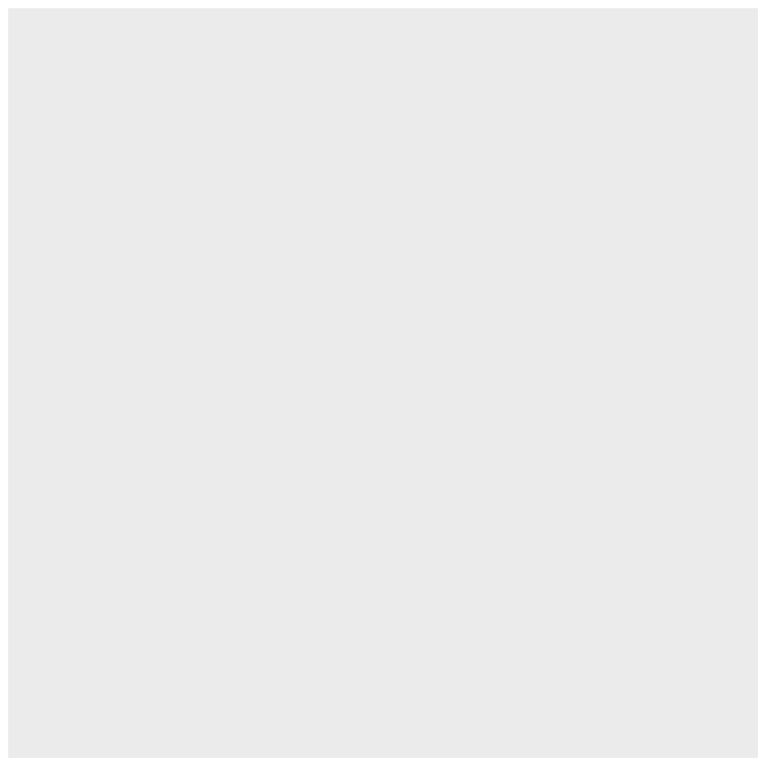

```r
# Initialize our ggplot object with some data
ggplot(data = metadata)
```

### 1.2.0.3 Every ggplot object consists of many parameters

We have, however, created a *ggplot object*. This is a list of 9 parameters:

1. data
2. layers
3. scales
4. mapping
5. theme
6. coordinates
7. facet
8. plot environment
9. labels.

Luckily there are some defaults, so we don't have to specify everything, but you can start to see how ggplot objects are highly customizable. So far, we have only specified the data aspect of this object.

```r
# Let's take a quick look at structure of a ggplot object
str(ggplot(metadata))
```

```
List of 9
 $ data       : tibble [81 x 7] (S3: spec_tbl_df/tbl_df/tbl/data.frame)
  ..$ Country       : chr [1:81] "Tanzania" "Tanzania" "Tanzania" "Tanzania" ...
  ..$ Latrine_Number: chr [1:81] "2" "2" "2" "2" ...
  ..$ Depth         : chr [1:81] "1" "10" "12" "2" ...
  ..$ pH            : num [1:81] 7.82 9.08 8.84 6.49 6.46 7.69 7.48 7.6 7.55 7.68 ...
  ..$ Temp          : num [1:81] 25.1 24.2 25.1 29.6 27.9 28.7 29.8 25 28.8 28.9 ...
  ..$ TS            : num [1:81] 14.5 37.8 71.1 13.9 29.4 ...
  ..$ CODt          : num [1:81] 874 102 35 389 161 57 107 62 384 372 ...
  ..- attr(*, "spec")=
  .. .. cols(
  .. ..   Country = col_character(),
  .. ..   Latrine_Number = col_character(),
  .. ..   Depth = col_character(),
  .. ..   pH = col_number(),
  .. ..   Temp = col_number(),
  .. ..   TS = col_number(),
  .. ..   CODt = col_number()
  .. .. )
 $ layers     : list()
 $ scales     :Classes 'ScalesList', 'ggproto', 'gg' <ggproto object: Class ScalesList, gg>
    add: function
    clone: function
    find: function
    get_scales: function
    has_scale: function
    input: function
    n: function
    non_position_scales: function
    scales: NULL
    super:  <ggproto object: Class ScalesList, gg>
 $ mapping    : Named list()
  ..- attr(*, "class")= chr "uneval"
 $ theme      : list()
 $ coordinates:Classes 'CoordCartesian', 'Coord', 'ggproto', 'gg' <ggproto object: Class CoordCartesian, Coord, gg>
    aspect: function
    backtransform_range: function
    clip: on
    default: TRUE
    distance: function
```

[output cut: 23 more lines]

```
    draw_labels: function
    draw_panels: function
    finish_data: function
    init_scales: function
    map_data: function
    params: list
    setup_data: function
    setup_params: function
    shrink: TRUE
    train_scales: function
    vars: function
    super:  <ggproto object: Class FacetNull, Facet, gg>
 $ plot_env   :<environment: R_GlobalEnv>
 $ labels     : Named list()
 - attr(*, "class")= chr [1:2] "gg" "ggplot"
```

### 1.2.0.4 `aes()` determines attributes of the mapping list and how data is displayed

The next step is to choose the data we are plotting **(aesthetics)**. At this point the data can be **scaled** and the axes appear. We have not yet specified how we want the data plot, just which data should be plotted. In practice, people usually omit 'mapping = ', but it is a good reminder that mapping is, in fact, what we are doing.

When we start customizing our plot, our code starts to get a bit harder to read on one line. We can create each specification on a new line by ending each line with `+`.

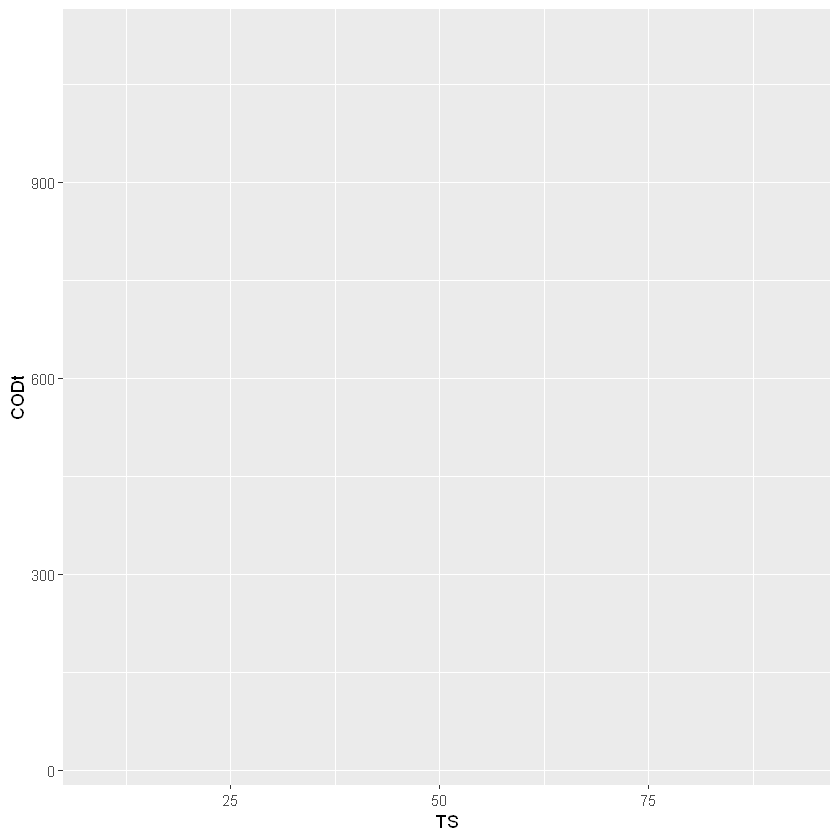

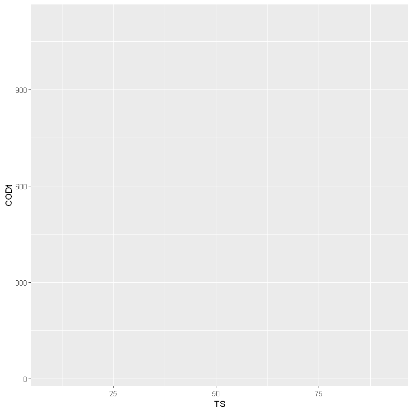

```r
# Add the aes() parameter to our plot
ggplot(data = metadata, mapping = aes(x = TS, y = CODt))

# We can make it equivalent by adding aes() like a layer
ggplot(data = metadata) +
    aes(x = TS, y = CODt)
```